# Analysis of clusters in an online customer survey

Alex Nikic

2025-12-18

This is an example notebook on how to use Harmony to analyse clusters in an online customer survey.

First we will import the Harmony library.

```r
# If you have not already installed Harmony, you can uncomment the following line of code.
# install.packages("harmonydata")

library(harmonydata)
```

Now we will load the CSV file containing the customer survey responses. The CSV file contains 100 responses of customers in a survey asking for feedback on a supermarket.

```r
df <- read.csv("survey_response.csv")
head(df)
```

|  | customer_id | response |
| --- | --- | --- |
| 1 | 1001 | The bakery section is fantastic! Always fresh bread and the staff are very friendly and helpful. |
| 2 | 1002 | Pricing is a bit high compared to competitors. I only shop here for specific sale items. |
| 3 | 1003 | I wish they had more organic produce options. The current selection is quite limited. |
| 4 | 1004 | Checkout lines are consistently long, even during off-peak hours. Need more cashiers open. |
| 5 | 1005 | The store is always clean and well-organized. It makes my weekly shop much less stressful. |
| 6 | 1006 | I had trouble finding the specific brand of cereal I needed. The aisle signage could be clearer. |

Now we will call Harmony to get the response from the server.

```r
instrument <- create_instrument_from_list(df$response)
match <- match_instruments(instrument)
```

We can view the clusters provided by Harmony using the following code.

```r
for (i in seq_along(match$clusters)) {
    print(paste0("Cluster ", match$clusters[[i]]$cluster_id, ": ", match$clusters[[i]]$text_description))

    keywords <- c()
    for (j in seq_along(match$clusters[[i]]$keywords)) {
        keywords <- c(keywords, match$clusters[[i]]$keywords[[j]])
    }
    keywords_output <- paste("Keywords:", paste(keywords, collapse = ", "))
    cat(keywords_output, "\n")

    for (j in seq_along(match$clusters[[i]]$item_ids)) {
        id <- match$clusters[[i]]$item_ids[[j]]
        cat(paste("    ", match$questions[[id]]$question_text, "\n"))
    }
    cat("\n")
}
```

```
## [1] "Cluster 1: The bakery section is fantastic! Always fresh bread and the staff are very friendly and helpful."
## Keywords: friendly, bread, bakery, counter, efficient
##      The bakery section is fantastic! Always fresh bread and the staff are very friendly and helpful.
##      The deli counter staff are knowledgeable and polite. Excellent quality meats and cheeses.
##      Excellent baked goods, especially the artisan bread. Keep up the good work!
##      Friendly cashier named Sarah always makes my day! Great customer service.
##      The bakery is amazing, but please stop packaging hot items in plastic bags—they sweat!
##      The clearance section always yields some great deals!
##      The pharmacy counter staff are very professional and efficient.
##      The employees genuinely seem to enjoy their jobs, which creates a good atmosphere.
##
## [1] "Cluster 2: Pricing is a bit high compared to competitors. I only shop here for specific sale items."
## Keywords: crept, noticeably
##      Pricing is a bit high compared to competitors. I only shop here for specific sale items.
##      Prices have crept up noticeably over the last six months.
##      I only come here for the discounted items near closing time. Good value then.
##      The price tags are often missing or placed on the wrong item. Confusing!
##
## [1] "Cluster 3: Customer service desk was unhelpful when I tried to return an item. Poor experience."
## Keywords: policy, returns, item
##      Customer service desk was unhelpful when I tried to return an item. Poor experience.
##      Staff are often hard to find when I need assistance in an aisle.
##      Love the new 'click and collect' service! It saves me so much time.
##      The manager was quick to resolve an issue I had with a billing error. Very professional.
##      I use the app for coupons, but they rarely scan properly at the register.
##      The returns policy is confusing and poorly explained on the website.
##      Excellent returns policy—very hassle-free when I brought back a spoiled item.
##
## [1] "Cluster 4: The fresh fruit and vegetables are consistently ripe and last a long time after purchase."
## Keywords: fruit, consistently, beautifully, displayed, market
##      The fresh fruit and vegetables are consistently ripe and last a long time after purchase.
##      I visit solely for the fresh-cut fruit packages. They are consistently delicious.
##      I find the fresh herb plants often look wilted or dead. Needs better care.
##      The produce department is beautifully displayed and organized like a market.
##
## [1] "Cluster 5: They really need better security in the parking lot; I've noticed suspicious activity."
## Keywords: lot, better, parking, lifesaver, play
##      Parking lot is a nightmare, especially on weekends. It needs better traffic management.
##      They really need better security in the parking lot; I've noticed suspicious activity.
##      The lighting in the car park needs to be improved; it feels unsafe after dark.
```

[output cut: 92 more lines]

```
##      Too much clutter near the entrance, making it hard to get my cart.
##      The parking spaces are too small, leading to frequent door dings.
##      The store is spacious and easy to maneuver a large cart through.
##      The store seems to be understaffed, leading to long waits and un-tended aisles.
##
## [1] "Cluster 16: The checkout staff are too quick and damage my delicate items when bagging."
## Keywords: checkout, pleasant, rushed, overworked, delicate
##      Checkout lines are consistently long, even during off-peak hours. Need more cashiers open.
##      The self-checkout machines break down too often. It’s frustrating when you have a small order.
##      The meat department always has a great variety of cuts, though it can be slightly expensive.
##      I wish there were more express checkouts for people with 10 items or less.
##      Fantastic staff—a young man helped me carry my groceries to the car in the rain.
##      Staff are pleasant, but they seem overworked and rushed.
##      The check-out operator was too busy talking to a colleague and ignored me.
##      The checkout staff are too quick and damage my delicate items when bagging.
```

We can view the size of each cluster.

```r
cluster <- c()
size <- c()

for (i in seq_along(match$clusters)) {
    cluster <- append(cluster, match$clusters[[i]]$text_description)
    size <- append(size, length(match$clusters[[i]]$item_ids))
}

cluster_df <- data.frame(
  id = seq(1:length(match$clusters)),
  cluster = cluster,
  size = size
)
cluster_df
```

| id | cluster | size |
| --- | --- | --- |
| 1 | The bakery section is fantastic! Always fresh bread and the staff are very friendly and helpful. | 8 |
| 2 | Pricing is a bit high compared to competitors. I only shop here for specific sale items. | 4 |
| 3 | Customer service desk was unhelpful when I tried to return an item. Poor experience. | 7 |
| 4 | The fresh fruit and vegetables are consistently ripe and last a long time after purchase. | 4 |
| 5 | They really need better security in the parking lot; I've noticed suspicious activity. | 6 |
| 6 | The fresh juice bar is a great addition! Love the daily blends. | 6 |
| 7 | I appreciate the effort they put into seasonal displays and product offerings. | 6 |
| 8 | The children's riding trolleys are always occupied or broken. | 2 |
| 9 | Good balance of price and quality. My go-to for a reliable weekly shop. | 10 |
| 10 | There's a persistent, unpleasant smell near the dairy section. Needs investigation. | 4 |

[output cut: 6 more lines]

Harmony picks one of the items in each cluster to act as a representative (centroid) for the cluster. We can gain a more informative summary of the content of each cluster by querying OpenAI.

You can protect your API key in R using the following method. This way when you distribute this notebook, you are not inadvertently exposing your API key.

If you type in the R console the following command:

```
file.edit("~/.Renviron")
```

you can input your secret API key.

```
OPENAI_API_KEY = "your_open_ai_key_here"
```

Then after restarting R, the API key will be loaded up and can be accessed as follows.

```r
api_key <- Sys.getenv("OPENAI_API_KEY")
```

Now we can send a request to OpenAI asking it to summarise each cluster.

```r
library(httr)
library(jsonlite)

# Prepare headers
headers <- add_headers(
  Authorization = paste("Bearer", api_key),
  `Content-Type` = "application/json"
)

openai_outputs <- c()

for (i in seq_along(match$clusters)) {

  all_inputs <- list(
    list(
      role = "system",
      content = "Give a topic title for the following list of survey responses. Do not give any other output."
    )
  )

  # Add each question to the list
  for (j in seq_along(match$clusters[[i]]$item_ids)) {
        id <- match$clusters[[i]]$item_ids[[j]]
        question_text <- match$questions[[id]]$question_text
        all_inputs <- append(all_inputs, list(
          list(
            role = "user",
            content = question_text
          )
        ))
  }

  # JSON body
  json_data <- list(
    model = "gpt-4.1",
    input = all_inputs
  )

  # Make POST request to OpenAI
  response <- POST(
    url = "https://api.openai.com/v1/responses",
    headers,
    body = toJSON(json_data, auto_unbox = TRUE)
  )

  # Parse response
  res_content <- content(response, as = "parsed", simplifyVector = TRUE)
  openai_title <- res_content$output$content[[1]]$text
  openai_outputs <- append(openai_outputs, openai_title)
}
```

Let’s view the new titles.

```r
cluster_df$openai_title <- openai_outputs
cluster_df
```

| id | cluster | size | openai_title |
| --- | --- | --- | --- |
| 1 | The bakery section is fantastic! Always fresh bread and the staff are very friendly and helpful. | 8 | Customer Feedback on Store Services and Staff Experience |
| 2 | Pricing is a bit high compared to competitors. I only shop here for specific sale items. | 4 | Customer Perceptions of Pricing and Value |
| 3 | Customer service desk was unhelpful when I tried to return an item. Poor experience. | 7 | Customer Service Experience |
| 4 | The fresh fruit and vegetables are consistently ripe and last a long time after purchase. | 4 | Feedback on Freshness and Quality of Produce Department |
| 5 | They really need better security in the parking lot; I've noticed suspicious activity. | 6 | Facility and Parking Lot Safety and Maintenance Concerns |
| 6 | The fresh juice bar is a great addition! Love the daily blends. | 6 | Feedback on Food and Beverage Offerings and Amenities |
| 7 | I appreciate the effort they put into seasonal displays and product offerings. | 6 | Positive Customer Experiences at Grocery Stores |
| 8 | The children's riding trolleys are always occupied or broken. | 2 | Feedback on Shopping Trolley Condition and Availability |
| 9 | Good balance of price and quality. My go-to for a reliable weekly shop. | 10 | Customer Experiences and Feedback on Grocery Store Services and Environment |
| 10 | There's a persistent, unpleasant smell near the dairy section. Needs investigation. | 4 | Store Cleanliness and Organization Feedback |

[output cut: 6 more lines]

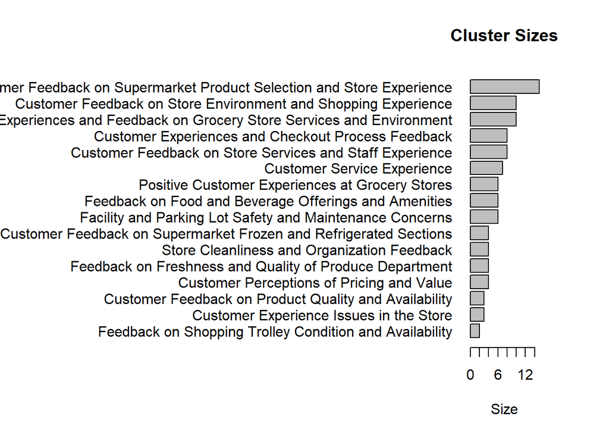

```r
par(mar = c(5, 27, 4, 4))

# Sort in descending order
cluster_df <- cluster_df[order(cluster_df$size, decreasing = FALSE), ]

barplot(
  height = cluster_df$size,
  names.arg = cluster_df$openai_title,
  horiz = TRUE,
  las = 1,                # horizontal text
  xlab = "Size",
  main = "Cluster Sizes"
)
```